© Guven

# Attention Mechanism in Neural Networks

## Introduction

```
"Attention is the rarest and purest form of generosity", Simone Weil
```

The attention mechanism in machine learning mimics the cognitive attention in order to set a context window similar to embeddings for feature extraction. It calculates *soft* weights for each word sequentially so it can address the weaknesses of RNNs, where words in a sentence are sequentially processed one at a time. This weakness is due to the sequential RNN favoring more recent words at the end of a sentence while earlier words fade away in volatile neural activations.

Attention mechanism can be applied sequentially, such as in recurrent neural networks, or can be applied in parallel, such as in transformers. The parallel application also helps unfolding the RNN, thus speeding up iterative processing at the cost of higher memory usage.

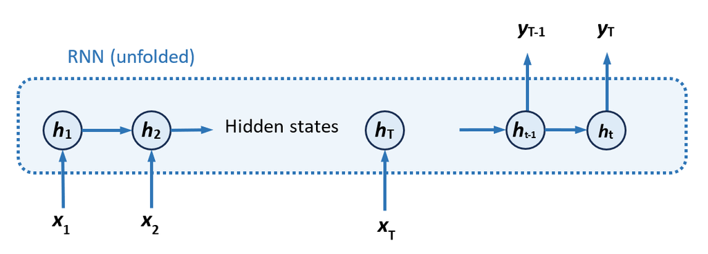

The attention mechanism gives all words equal access to any part of a sentence in a faster parallel scheme and no longer suffers the wait time of serial processing.

## Seq2seq with Attention

The decoder has to generate the entire output sequence based solely on the thought vector, i.e. the encoder-hidden layer. It is necessary that the thought vector has to encode all of the information about the input sequence but in an RNN this is not practical since the hidden state will carry more information about the later term than the earlier terms. Using LSTM cells and reversing the input is helpful but still order-dependent. As a result, the seq2seq model works well for short sentences, but the performance deteriorates for longer ones.

## Bahdanau attention

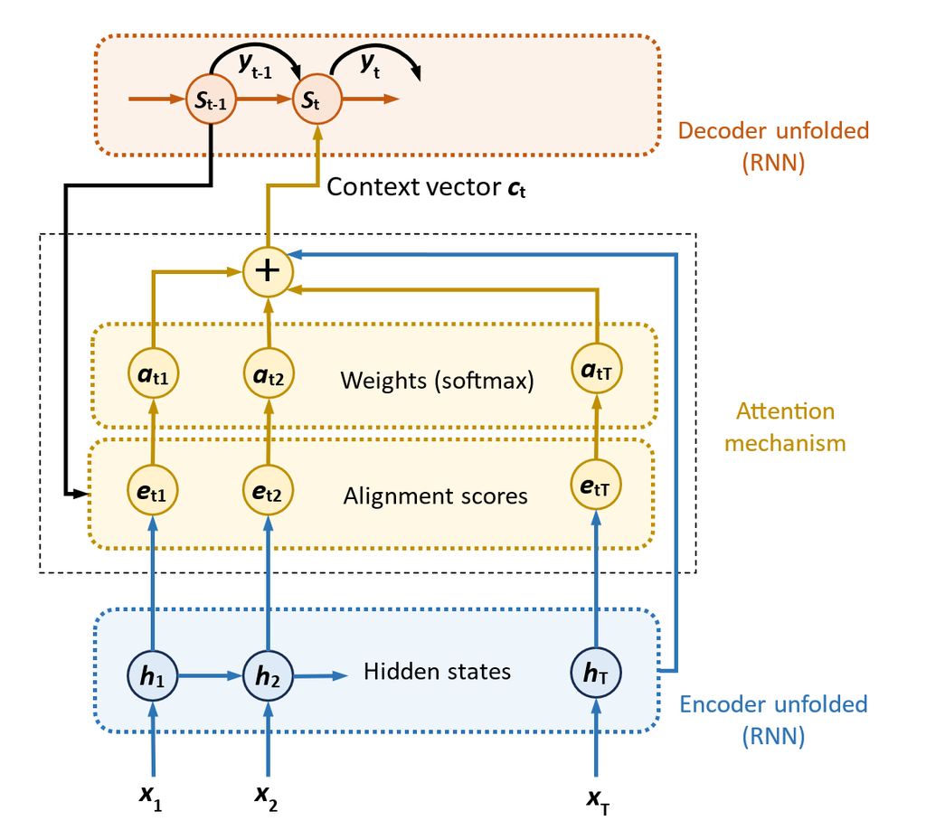

The attention mechanism (Bahdanau, 2014) is an extension of the seq2seq model which provides a way for the decoder to work with all encoder hidden states, not just the last one. Besides solving the thought bottleneck problem, the attention mechanism has other advantages, such as the immediate access to all previous states helps to prevent the vanishing gradients problem.

The hidden decoder state $s_t$ at time $t$ is a function of the hidden state $s_{t-1}$, decoder output at step $t-1$ as $y_{t-1}$, and the context vector $c_t$.

$c_t = \sum\limits_{i=1}^T \alpha_{t,i}h_i$

- $c_t$ is the context vector for a decoder output step $t$ out of $T'$, the total output
- $h_i$ is the hidden state of encoder step $i$ out of $T$ total input steps
- $\alpha_{t,i}$ is the scalar weight associated with $h_i$ in the context of the current decoder step $t$

Note that $\alpha_{t,i}$ is different for both the encoder and decoder steps, the input sequence states will have different weights depending on the current output step. For example, if the input and output sequences have lengths of $10$, then the weights will be represented by a $10 \times 10$ matrix for a total of $100$ weights. Thus, the attention mechanism will focus the attention of the decoder on different parts of the input sequence, depending on the current state of the output sequence. If $\alpha_{t,i}$ is large, then the decoder will pay a higher attention to $h_i$ at step $t$.

The sum of all $\alpha_{t,i}$ for a decoder at step $t$ is $1$ which can be implemented by a $\text{softmax}$ operation.

$\alpha_{t,i}=\frac{\exp(e_{t,i})}{\sum_{j=1}^T \exp(e_{t,j})}$

where $e_{t,k}$ is an alignment model, which indicates how well the input sequence elements around position $k$ match (or align with) the output at position $t$. This score (represented by the weight $\alpha_{t,i}$) is based on the previous decoder state $s_{t-1}$ (note that $s_t$ not computed yet), as well as the encoder state $h_i$,

$e_{t,i}= \mathbb{a}(s_{t-1,h_i})$

where, $\mathbb{a}$ is a differentiable function, which is trained with backpropagation together with the rest of the network. Different functions satisfy these requirements, but the authors of the paper called it **additive attention**, which combines $s_{t-1}$ and $h_i$ with the help of addition. It can be,

- $e_{t,i} = \mathbb{a}(s_{t-1},h_i) = v^T \tanh(W[h_i;s_{t-1}])$
- $e_{t,i} = \mathbb{a}(s_{t-1},h_i) = v^T \tanh(W_1 h_i + W_2 s_{t-1})$

The $W$ is a weight matrix, applied over the concatenated vectors $s_{t-1}$ and $h_i$, and $v$ is a weight vector. The alignment model can be represented as a simple feed forward network with one hidden layer.

## Luong attention

Several improvements added to Bahdanau attention. The alignment scores $e_t$ depend on the decoder hidden state $s_t$, as opposed to $s_{t-1}$ in Bahdanau attention.

The Luong attention also proposed two types of **multiplicative attention**,

- $e_{t,i}=s_t^T h_i$
- $e_{t,i}=s_t^T W_m h_i$

Note that the dot product acts as a similarity measure between vectors.

## Hard Attention

The hard and soft attention variants relate to the context vector $c_t$. Hard attention computes the weights $\alpha_{t,i}$, and it only takes the hidden state $h_{imax}$ with the maximum associated weight $\alpha_{t,imax}$. Then, the selected state $h_{imax}$ serves as the context vector. Hard attention limits it to a single state again, for a good reason in the context of image recognition tasks, where the input sequence represents different regions of the same image. In such cases, it is better to choose between multiple regions, or a single region. Unlike soft attention, hard attention is a stochastic process, which is non-differentiable.

## Local Attention

It represents a compromise between soft and hard attention. Whereas these mechanisms take into account either all input hidden vectors (global) or just a single input vector, local attention takes a window of vectors, surrounding a given input sequence location, and then applies soft attention over this window only. The center of the window position $p_t$ (aka the aligned position) is picked according to the current output step $t$ by assuming that the source and target sequences are roughly monotonically aligned.

## General Attention

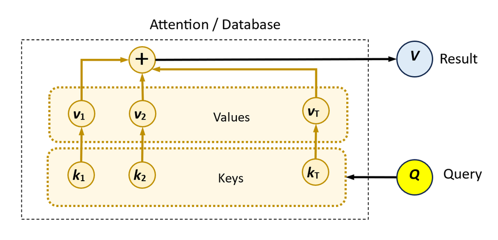

Hard attention, the query ($q=s_{t-1}$) against the database receives a single match, the key $k_{imax}$ with the maximum weight $\alpha_{t,imax}$. Hidden behind this key is the vector $v_{imax}=h_{imax}$, which is the actual value required. The soft attention, where all values participate, can be the query results via all values with different weights. Thus, a generalized attention formula (based on the context vector $c_t$ formula) using the new notation,

$\alpha_{q,k_i}=\frac{\exp(e_{q,k_i})}{\sum_j \exp(e_{q,k_j})}$

$\text{Attention}(q,K,V) = \sum\limits_i \alpha_{q,k_i} V_{k_i}$

In this generic attention, the queries, keys, and vectors of the database are not necessarily related in a sequential fashion. In other words, the database does not have to consist of the hidden RNN states at different steps, but could contain any kind of information instead.

### Self Attention

It is the attention mechanism relating different positions of a single sequence in order to compute a representation of the same sequence (aka intra attention). Some example applications are machine reading, abstractive summarization, or image description generation.

### Summary

| Name | Score | Reference |
| --- | --- | --- |
| Content-based | $\operatorname{score}(\mathbf{s}_t,\mathbf{h}_i) = \operatorname{cosine}[\mathbf{s}_t,\mathbf{h}_i]$ | Graves14 |
| Additive | $$\operatorname{score}(\mathbf{s}_t,\mathbf{h}_i) = v_a^\top \operatorname{tanh}(\mathbf{W}_a [\mathbf{s}_t,\mathbf{h}_i])$$ | Bahdanau15 |
| Location-based | $\alpha_{t,i} = \operatorname{softmax}(\mathbf{W}_a \mathbf{s}_t)$ | Loung15 |
| General | $\operatorname{score}(\mathbf{s}_t,\mathbf{h}_i) = \mathbf{s}_t^\top \mathbf{W}_a \mathbf{h}_i$ | Loung15 |
| Dot-product | $\operatorname{score}(\mathbf{s}_t,\mathbf{h}_i) = \mathbf{s}_t^\top \mathbf{h}_i$ | Loung15 |
| Scaled dot-product | $\operatorname{score}(\mathbf{s}_t,\mathbf{h}_i) = \frac{\mathbf{s}_t^\top \mathbf{h}_i}{\sqrt n}$ | Vaswani17 |

## Multi-head Attention Mechanism

Self-attention involves three matrices `Q`, `K` and `V` all derived from the original corpus and the input `X` $\in \mathbb{R}^{d_x \times d_{\text{model}}}$ where there are $d_x$ tokens in the sequence and an embedding of size $d_{\text{model}}$. The original length of the sequence is either $d_x$ or truncated to $d_x$. All three matrices `Q` (query $\theta$), `K` (key $\Phi$) and `V` (value $\mathbf{g}$) are achieved multiplying the `X` matrix by $\Theta$, $\Phi$, and $\mathbf{g}$, respectively. The values (weights) of these matrices are trained by the learning process.

`Q` and `K` multiplied to each other generates the attention score matrix. This can also be seen as a database using the query and keys in order to find out how much various items are related. Multiplication of the attention score and `V` produces the final result.

$\operatorname{Attention}(Q,K,V) = V \operatorname{softmax}(\operatorname{score}(Q,K))$

Similar to neural network training, `Q`, `K` and `V` are initialized randomly with a particular distribution (e.g. zero mean a low standard deviation normal) and then trained with the corpus.

Multi-head attention repeats this process for a $k$ number of times and concatenates the output linearly to achieve parallelism. If there are $k$ heads then the output attention will be $Z = (z_0,z_1,\dots,z_{k-1})$ partitioned over $\frac{d_{\text{model}}} {k}$, embedding dimension size.

## Multi-head Attention Example

The multi-head attention block is the main innovation behind transformers. This block finds out what parts of the text should the model focus on. A single attention block can set a model to *pay attention* to something specific such as the verb in a sentence. Using multiple attention blocks can focus to different linguistic elements such as part of speech, nouns, verbs, adjectives, etc.

```python
# Manual computation in Python

import numpy as np
import pandas as pd

from scipy.special import softmax

# self attention
# d_x=3, d_model=4, arbitrary values
x = np.array([[1., 0., 1., 0.], [0., 2., 0., 2.], [1., 1., 1., 1.]])  # input/token 1, 2, 3
w_Q = np.array([[1, 0, 1], [1, 0, 0], [0, 0, 1], [0, 1, 1]])
w_K = np.array([[0, 0, 1], [1, 1, 0], [0, 1, 0], [1, 1, 0]])
w_V = np.array([[0, 2, 0], [0, 3, 0], [1, 0, 3], [1, 1, 0]])

Q = np.matmul(x,w_Q)
K = np.matmul(x,w_K)
V = np.matmul(x,w_V)

d_x = 3
attention_score = (Q @ K.transpose()) / np.sqrt(d_x)
attention = V @ softmax(attention_score)

print(attention)
```

```
[[4.21949168e-03 1.86274277e+00 2.37831459e-01]
 [6.85126140e-03 6.48367499e+00 6.45393292e-01]
 [7.64512238e-03 5.10458026e+00 5.60528104e-01]]
```

## Improved Seq2Seq Translation

Let's see an example of sequence to sequence network where two recurrent neural networks work together to transform one sequence to another.

Demonstrate a translation with the english-french dataset (Sutskever, 2014). The module file `nmt_dataset.py`, neural machine translation Python script, helps load the dataset `eng-fra.txt` TSV file. Place this script in the same folder.

```python
%matplotlib inline
import matplotlib.pyplot as plt
import matplotlib.ticker as ticker
plt.rcParams['figure.dpi'] = 72
from IPython.display import display
import numpy as np
import sys
```

```python
import torch
import torch.nn as nn

Gpu = torch.device("cuda:0" if torch.cuda.is_available() else "cpu")

print(f'PyTorch version= {torch.__version__}')
print(f'CUDA available= {torch.cuda.is_available()}')

# The script runs fast on a CPU due to one sequence at a time learning
```

```
PyTorch version= 2.0.1
CUDA available= True
```

```python
sys.path.insert(1, './nmt_dataset/.')

from nmt_dataset import NMTDataset, GO_token, EOS_token, MAX_LENGTH

DATASET_SIZE = 100000  # skipping some rows

dataset = NMTDataset('nmt_dataset/eng-fra.txt', DATASET_SIZE)
```

```python
HIDDEN_N= 128

class Encoder(torch.nn.Module):
    def __init__(self, n_input, n_hidden):
        super().__init__()
        self.n_input, self.n_hidden = n_input, n_hidden

        # embedding layer
        self.embedding = torch.nn.Embedding(self.n_input, self.n_hidden)

        # RNN cell
        self.rnn_cell = torch.nn.GRU(self.n_hidden, self.n_hidden)

    def forward(self, _X, _hn):
        # single sequence
        X_embedded = self.embedding(_X).view(1, 1, -1)
        output, hn = self.rnn_cell(X_embedded, _hn)
        return output, hn

    def init_hidden(self):
        return torch.zeros(1, 1, self.n_hidden, device=Gpu)

class Decoder(torch.nn.Module):
    def __init__(self, n_hidden, n_output, dropout=0.1):
        super().__init__()
        self.n_hidden, self.n_output = n_hidden, n_output

        self.embedding = torch.nn.Embedding(self.n_output, self.n_hidden)

        self.dropout = torch.nn.Dropout(dropout)

        self.attn = torch.nn.Linear(in_features=self.n_hidden,
                                    out_features=self.n_hidden)

        self.w_c = torch.nn.Linear(in_features=self.n_hidden*2,
                                   out_features=self.n_hidden)

        self.rnn_cell = torch.nn.GRU(input_size=self.n_hidden,
                                     hidden_size=self.n_hidden)

        # output
        self.w_y = torch.nn.Linear(in_features=self.n_hidden,
                                   out_features=self.n_output)

    def forward(self, _X, _hn, _encoder_outputs):
        X_embedded = self.embedding(_X).view(1, 1, -1)
        X_embedded = self.dropout(X_embedded)

        # hidden state, time t
        rnn_out, hn = self.rnn_cell(X_embedded, _hn)

        # alignment scores
        alignment_scores = torch.mm(self.attn(hn)[0], _encoder_outputs.t())

        # weights
        attn_weights = torch.nn.functional.softmax(alignment_scores, dim=1)

        # multiplicative attention context vector c_t
        c_t = torch.mm(attn_weights, _encoder_outputs)

        # concatenate h_t and the context
        hidden_s_t = torch.cat([hn[0], c_t], dim=1)

        # hidden context
        hidden_s_t = torch.tanh(self.w_c(hidden_s_t))

        # output
        output = torch.nn.functional.log_softmax(self.w_y(hidden_s_t), dim=1)

        return output, hn, attn_weights

    def init_hidden(self):
        return torch.zeros(1, 1, self.n_hidden, device=Gpu)
```

```python
encoder = Encoder(dataset.input_lang.n_words, HIDDEN_N).to(Gpu)
decoder = Decoder(HIDDEN_N, dataset.output_lang.n_words, dropout=0.1).to(Gpu)

dt_loader = torch.utils.data.DataLoader(dataset, batch_size=1, shuffle=False)
N = len(dt_loader.dataset)

e_optim = torch.optim.Adam(encoder.parameters())
d_optim = torch.optim.Adam(decoder.parameters())
loss_func = torch.nn.NLLLoss()
```

```python
def train(_enc, _dec, info=False):
    totloss = 0
    for i, (seq1, seq2) in enumerate(dt_loader):
        seq1 = seq1.to(Gpu).squeeze(0)
        seq2 = seq2.to(Gpu).squeeze(0)

        e_hn = _enc.init_hidden()  # hidden layer

        e_optim.zero_grad()
        d_optim.zero_grad()

        Nseq1 = seq1.size(0)  # input length
        Nseq2 = seq2.size(0)  # target length

        e_outputs = torch.zeros(MAX_LENGTH, _enc.n_hidden, device=Gpu)

        loss = torch.Tensor([0]).squeeze().to(Gpu)

        with torch.set_grad_enabled(True):
            # encoder
            for ei in range(Nseq1):
                e_output, e_hn = _enc(seq1[ei], e_hn)
                e_outputs[ei] = e_output[0, 0]

            # init decoder with GO_token
            d_input = torch.tensor([[GO_token]], device=Gpu)

            d_hn = e_hn  # hidden layer

            for di in range(Nseq2):
                d_output, d_hn, d_attn = _dec(d_input, d_hn, e_outputs)
                loss += loss_func(d_output, seq2[di])
                d_input = seq2[di]

            loss.backward()

            e_optim.step()
            d_optim.step()

        totloss += loss.item()/Nseq2

        DBG_STEP = 1000
        if info:
            if i % DBG_STEP == 0:
                sys.stderr.write(f"\r{i//DBG_STEP:3d}/{N//DBG_STEP:3d} | Loss: {totloss/DBG_STEP:3.2f}")
                sys.stderr.flush()
                totloss = 0
```

```python
%%time

train(encoder, decoder, info=True)
```

```
 99/100 | Loss: 0.58
```

```
CPU times: total: 31min 57s
Wall time: 31min 56s
```

```python
def eval_ss(_enc, _dec, _seq1, max_length=MAX_LENGTH):
    with torch.no_grad():
        Nseq1 = _seq1.size()[0]
        e_hn = _enc.init_hidden()
        _seq1.to(Gpu)

        e_outputs = torch.zeros(max_length, _enc.n_hidden, device=Gpu)

        for ei in range(Nseq1):
            e_output, e_hn = _enc(_seq1[ei], e_hn)
            e_outputs[ei] += e_output[0, 0]

        d_input = torch.tensor([[GO_token]], device=Gpu)

        d_hn = e_hn  # hidden layer

        d_words = []
        d_attentions = torch.zeros(max_length, max_length)

        for di in range(max_length):
            d_output, d_hn, d_attn = _dec(d_input, d_hn, e_outputs)
            d_attentions[di] = d_attn.data

            # output word index with highest P
            _, topi = d_output.data.topk(1)
            if topi.item() != EOS_token:
                d_words.append(dataset.output_lang.index2word[topi.item()])
            else:
                break

            d_input = topi.squeeze().detach()

        return d_words, d_attentions[:di+1]


def eval_rnd(_enc, _dec, n=10):
    import random
    for _ in range(n):
        sample = random.randint(0, N-1)
        pair = dataset.pairs[sample]
        seq1 = dataset[sample][0].to(Gpu)

        output_words, attentions = eval_ss(_enc, _dec, seq1)

        print(f"seq1:{pair[0]} | seq2:{pair[1]} | result:{' '.join(output_words)}")
```

```python
eval_rnd(encoder, decoder)
```

```
seq1:je suis vraiment en colere la . | seq2:i m really angry right now . | result:i m really angry .
seq1:il est bon chanteur . | seq2:he is good at singing . | result:he is a good singer .
seq1:je ne suis sure de rien . | seq2:i m not sure of anything . | result:i m not sure of anything .
seq1:je suis desolee je ne vous reconnais pas . | seq2:i m sorry i don t recognize you . | result:i m sorry i don t recognize you .
seq1:vous n etes pas encore adolescent . | seq2:you re not a teenager yet . | result:you re not a teenager yet .
seq1:je vais etre a l exterieur aujourd hui . | seq2:i m going to be out today . | result:i m going to be much today .
seq1:je prends mon livre avec moi . | seq2:i m taking my book with me . | result:i m taking with my book .
seq1:nous jouons au tennis ce week end . | seq2:we are playing tennis this weekend . | result:we are playing tennis this place .
seq1:vous etes plus grand que moi . | seq2:you re taller than i am . | result:you re smarter than me .
seq1:tu es sur la bonne pente . | seq2:you re on the right track . | result:you re on the one of that .
```

```python
def plot_attention(_seq1, _seq2, _attentions):
    fig = plt.figure(figsize=(4, 4), dpi=72)
    ax = fig.add_subplot(111)
    cax = ax.matshow(_attentions, cmap='gray')
    fig.colorbar(cax, fraction=0.03, pad=0.1)
    _seq1 = _seq1.split(' ')
    _seq2 = _seq2.split(' ')
    ax.xaxis.tick_top()
    ax.set_xticks(np.arange(len(_seq1)))
    ax.set_yticks(np.arange(len(_seq2)))
    ax.set_xticklabels(_seq1, rotation=90)
    ax.set_yticklabels(_seq2)
    plt.show()

def eval_plot(_enc, _dec, _seq1):
    seq2, attentions = eval_ss(_enc, _dec, dataset.sentence_to_sequence(_seq1).to(Gpu))
    _seq1 += ' <EOS>'
    seq2 = ' '.join(seq2) + ' <EOS>'
    print(f"seq1: {_seq1} | seq2: {seq2}")
    plot_attention(_seq1, seq2, attentions.numpy())
```

```
seq1: je ne compare pas tom a mary . <EOS> | seq2: i m not sure we ll reason . <EOS>
```

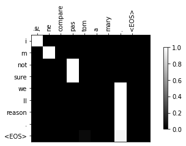

```
seq1: elle est trop petit . <EOS> | seq2: she is too short . <EOS>
```

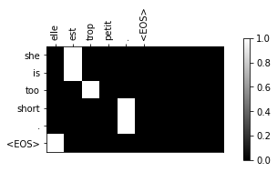

```
seq1: je ne crains pas de mourir . <EOS> | seq2: i m not afraid of death . <EOS>
```

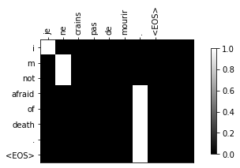

```
seq1: tu es parfois si pueril . <EOS> | seq2: you are so childish sometimes . <EOS>
```

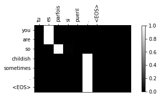

```python
eval_plot(encoder, decoder, 'je ne compare pas tom a mary .')
eval_plot(encoder, decoder, 'elle est trop petit .')
eval_plot(encoder, decoder, 'je ne crains pas de mourir .')
eval_plot(encoder, decoder, 'tu es parfois si pueril .')
```

## References

1. Vasilev, Ivan. Advanced Deep Learning with Python: Design and implement advanced next-generation AI solutions using TensorFlow and PyTorch. Packt Publishing Ltd, 2019.
2. Sutskever, Ilya, Oriol Vinyals, and Quoc V. Le. "Sequence to sequence learning with neural networks." Advances in neural information processing systems 27 (2014).
3. Bahdanau, Dzmitry, Kyunghyun Cho, and Yoshua Bengio. "Neural machine translation by jointly learning to align and translate." arXiv preprint arXiv:1409.0473 (2014).
4. Vaswani, Ashish, et al. "Attention is all you need." Advances in neural information processing systems 30 (2017).

## Exercises

**Exercise 1.** Try different datasets for seq2seq problem.

**Exercise 2.** Try the multiplicative attention.

```python
%%html
<style>
    table {margin-left: 0 !important;}
</style>
<!-- Display markdown tables left oriented in this notebook. -->
```